# Lab 12- IRT (1): Unidimensional Logistic IRT

Kyle Chan

October 12, 2020

# Introduction to the Item Response Theory (IRT)

The Item Response Theory (IRT) looks at the underlying traits of individuals/ observations. Given a series of responses, we want to discover the individual’s trait (broadly defined) from the pattern of responses. It originated from the education literature, where researchers want to identify a person’s ability (which is a latent trait) having observed their responses to the test.

In Political Science, one can imagine using IRT to model on latent traits such as political knowledge (Tsai and Lin 2017); Democracy (Treier and Jackman 2008); Ideology of Judges (Martin and Quinn 2002), so on and so forth.

Most IRT models are unidimensional, meaning that we only measure one latent trait from the data. However, there are other IRT models that allow the recovery of multiple latent traits (polytomous IRT models). We will focus on those next week.

# The Rasch Model

To understand what the IRT model is doing, we start with a very simple problem of modeling two unknown quantities at the same time. Suppose we only observe an individual’s response in a TRUE/FALSE question, so we know that $Y_i \in \{0,1\}$, where $Y_i = 1$ refers to a correctly answered question, and $Y_i = 0$ refers to an incorrect answer. We want to know simultaneously, 1) individual $i$’s ability: $\theta_n$, and controlling for 2) the question’s difficulty ($b_i$). We can then model the probability of observing a correct answer with the following model:
$$P(Y_i = 1 | \theta_n, b_i) = \frac{exp(\theta_n - b_i)}{1 + exp(\theta_n - b_i)}$$
This is called a Rasch model. The ability parameter $\theta_n$ is non-linearly related to only the item difficulty ($b_i$).

Notice that the model is highly similar to a logistic regression model, except that the parameters are not directly observed.

If one plots the joint probability $P(\theta, b_i)$ against ability $\theta$, one gets a non-linear curve that characterizes the relationship between the probability of observing a correct response and a person’s ability ($\theta$). We call this an Item Characteristic Curve (ICC). Figure 1 shows an example of the ICC.

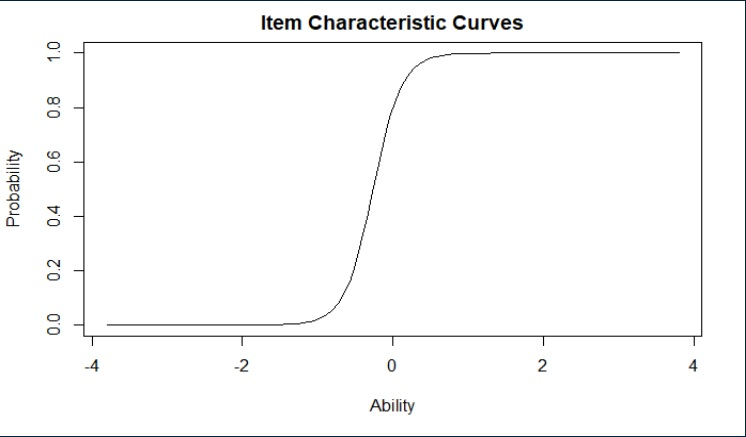

Figure 1. Item Characteristic Curve (ICC)

# The Two Parameter Logistic Model (2PL)

We then generalize the Rasch model by adding one unobserved quantity, $a$, which has a substantive intepretation as the discrimination or slope of the Item Characteristic Curve (ICC). This is called a 2-parameter logistic IRT model (2PL), which comes in the form of:
$$P(y=1 | \theta, a, b) = \frac{1}{1+exp(-(a\theta + b))}$$

# Adding even more parameters

One can add even more parameters to the model. For example, people sometimes add a third parameter $g$ to model the probability of randomly answering correctly (guessing). One can even add a fourth element $u$, which has a substantive intepretation as the probability of randomly answering incorrectly. The model then takes the form of:
$$P(y=1 | \theta, a, b, u , g) = \frac{(u-g)}{1+exp(-(a\theta + b))}$$

# Exercise: Immigration Attitudes expressed by voters in the 2018 Midterm Election

The 2018 Cooperative Congressional Election Survey (CCES) dataset contains a couple of questions poking at people’s immigration attitudes. They asked if people support or oppose a series of policy proposals related to immigration:

`CC18_322a` - Increase spending on border security by $25 billion, including building a wall between the U.S. and Mexico

`CC18_322b`- Provide legal status to children of immigrants who are already in the United States and were brought to the United States by their parents. Provide these children the option of citizenship in 10 years if they meet citizenship requirements and commit no crimes. (DACA).

`CC18_322c_new` - Reduce legal immigration by eliminating the visa lottery and ending family-based migration.

`CC18_322d_new` - Grant legal status to DACA children, spend $25 billion to build the border wall, and reduce legal immigration by eliminating the visa lottery and ending family-based migration

`CC18_322c`- Withhold federal funds from any local police department that does not report to the federal government anyone they identify as an illegal immigrant

`CC18_322f` - Send to prison any person who has been deported from the United States and reenters the United States.

With IRT models, we might be able to gauge people’s latent attitudes to immigration (pro-immigration vs. anti-immigration) from this battery of 6 questions.

Fit an appropriate IRT model to estimate people’s immigration attitudes. Remember to recode NAs and responses to ensure that all questions are following the same direction (e.g. all “support” answers should point towards a pro-immigration position).

```r
library(readr)
library(tidyverse)
setwd("C:/Users/Kyle/Google Drive/TA/20 Fall - 787/GitHub-repo/POLI-787-2020-FALL-Internal/lab data")
cces18 <- read_delim("cces18_common_vv.tab",
    "\t", escape_double = FALSE, trim_ws = TRUE)
im <- cces18 %>% dplyr::select(CC18_322a, CC18_322b, CC18_322c_new, CC18_322d_new, CC18_322c, CC18_322f)

#Recode variables
im$CC18_322b <- ifelse(im$CC18_322b == 1, 2, 1)
im$CC18_322d_new <- ifelse(im$CC18_322d_new == 1, 2, 1)

#so now value of 1 ~ pro-immigration, value of  2~ anti-immigration.

#coerce into 0 and 1
im <- apply(im, 2, FUN= function(x) x-1)
im <- as.data.frame(im)
```

Load package `ltm` and call `descript()` on the cleaned dataset. Inspect the “Pairwise Associations” table of chi-square correlations. Are the items correalted? If not, then IRT may not be appropriate for this subset of the data.

```r
library(ltm)
#Descriptives
descript(im)
```

```
##
## Descriptive statistics for the 'im' data-set
##
## Sample:
##  6 items and 60000 sample units; 3259 missing values
##
## Proportions for each level of response:
##                    0      1   logit
## CC18_322a     0.4082 0.5918  0.3715
## CC18_322b     0.2475 0.7525  1.1118
## CC18_322c_new 0.4216 0.5784  0.3163
## CC18_322d_new 0.6662 0.3338 -0.6908
## CC18_322c     0.4641 0.5359  0.1438
## CC18_322f     0.5180 0.4820 -0.0721
##
## Missing responses:
##      CC18_322a CC18_322b CC18_322c_new CC18_322d_new CC18_322c CC18_322f
## Freq   315.000  140.0000     1334.0000       1344.00   55.0000   71.0000
## (%)      0.525    0.2333        2.2233          2.24    0.0917    0.1183
##
##
## Frequencies of total scores:
##         0    1     2    3     4     5    6
## Freq 5189 6185 10504 7566 10062 18213 2281
##
##
## Point Biserial correlation with Total Score:
##               Included Excluded
## CC18_322a       0.7752   0.6152
## CC18_322b       0.6788   0.5075
## CC18_322c_new   0.7300   0.5470
## CC18_322d_new  -0.1354  -0.3798
## CC18_322c       0.7959   0.6462
## CC18_322f       0.7340   0.5509
##
##
## Cronbach's alpha:
##                          value
## All Items               0.6458
## Excluding CC18_322a     0.5056
## Excluding CC18_322b     0.5593
## Excluding CC18_322c_new 0.5342
## Excluding CC18_322d_new 0.8271
## Excluding CC18_322c     0.4903
## Excluding CC18_322f     0.5318
##
##
## Pairwise Associations:
##    Item i Item j p.value
## 1       2      4   6e-13
## 2       1      2  <2e-16
## 3       1      3  <2e-16
## 4       1      4  <2e-16
## 5       1      5  <2e-16
## 6       1      6  <2e-16
## 7       2      3  <2e-16
## 8       2      5  <2e-16
## 9       2      6  <2e-16
## 10      3      4  <2e-16
```

```r
#Rasch Model (no control over slope of the ICC)
```

Basically every item is correlated in our example. This makes sense, as they are all asked on the issue of immigration. We can now move on.

## The Rasch Model

Now fit a Rasch model using `rasch()`. Remember, the Rasch model constrains the discrimination parameter = 1. You can indicate this by setting the constraint argument to a matrix containing K+1 and 1, indicating that we want the K+1 parameter (the discrimination parameter) to be fixed at 1. Once you are done fitting the model, acquire the results using `coef()`. If you set `prob` to `TRUE`, then you would be able to acquire $Pr(Y_i = 1 | \theta=0)$ - i.e. the tendency for the person with an average attitude to immigration agreeing to a statement.

```r
mod1 <- rasch(im, constraint = cbind(length(im)+1, 1))
coef(mod1, prob=TRUE, order=TRUE)
```

```
##                    Dffclt Dscrmn P(x=1|z=0)
## CC18_322b     -1.35166458      1  0.7944016
## CC18_322a     -0.44906618      1  0.6104172
## CC18_322c_new -0.37911922      1  0.5936607
## CC18_322c     -0.16793576      1  0.5418855
## CC18_322f      0.09861817      1  0.4753654
## CC18_322d_new  0.85562155      1  0.2982549
```

```r
#for me, 1 = pro-immigration.
#for me, the average person has a 79% probability of providing legal status to DACA children; 30% to oppose granting legal status to DACA children.
```

Explore the table. Which statement does the average person tend to (dis)agree the most? the least?

Let’s check the fit of the model. You can use `GoF.rasch()` to acquire a bootstrap goodness-of-fit test using a Pearson’s $\chi^2$ statistic. Here, the $H_0$ is that the the observed data have been generated under the Rasch model with parameter values of the maximum likelihood estimates $\hat{\theta}$ . To do this, we acquire up to $B$ samples and find how often the generated data follows the MLE.

```r
GoF.rasch(mod1, B=199)
```

```
##
## Bootstrap Goodness-of-Fit using Pearson chi-squared
##
## Call:
## rasch(data = im, constraint = cbind(length(im) + 1, 1))
##
## Tobs: 1028221
## # data-sets: 200
## p-value: 0.09
```

# The 2PL IRT

The Rasch model can only bring us so far. Let’s try fitting a more complicated 2PL model using `ltm()`. You can indicate up to 2 latent variables with `ltm()` like you would with `lm()`. The format is that `dataset ~ latent variables`. For example, if I only want to estimate one latent trait, the formula would then be `dataset~ z1`.

Once you’ve fitted the model, intepret the Difficulty and the Discrimination parameters.

```r
mod_2pl <- ltm(im ~ z1)
```

We can also make inference by comparing the 2PL IRT to the Rasch. You can do this by using `anova()` as usual. Does the 2PL IRT improve model fit?

```r
anova(mod1, mod_2pl)
```

```
##
##  Likelihood Ratio Table
##              AIC      BIC   log.Lik      LRT df p.value
## mod1    437310.2 437364.2 -218649.1
## mod_2pl 366297.0 366405.0 -183136.5 71025.21  6  <0.001
```

That is very large test statistic! Yes, the 2PL IRT model fitted much better than the Rasch model.

You can also visualize the fitted IRT models by calling `plot()`. Check `plot.ltm()` for details. Of particular interest is the ICC that we talked about earlier in the lab. Plot the ICC of the 2PL model. Which statements do pro-immigration respondents tend to agree? Which statements do they tend to disagree?

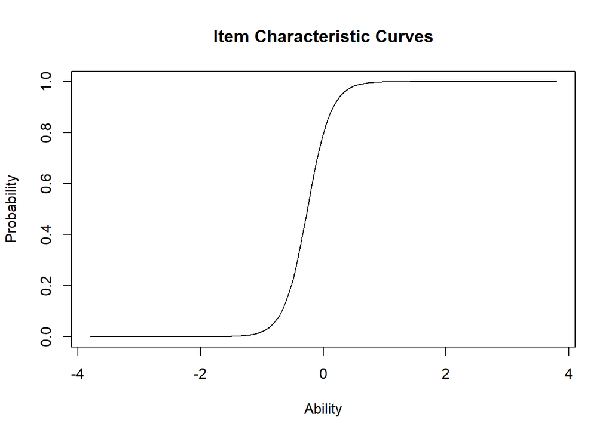

```r
plot(mod_2pl, item = 1)
```

Now plot the Item Information Curves (IIC). You can specify this by setting `type="IIC`. What the IIC shows is how much leverage does each of them item to provide conditional on the position of the latent trait. Plot the IIC of the 2PL model and intepret the results.

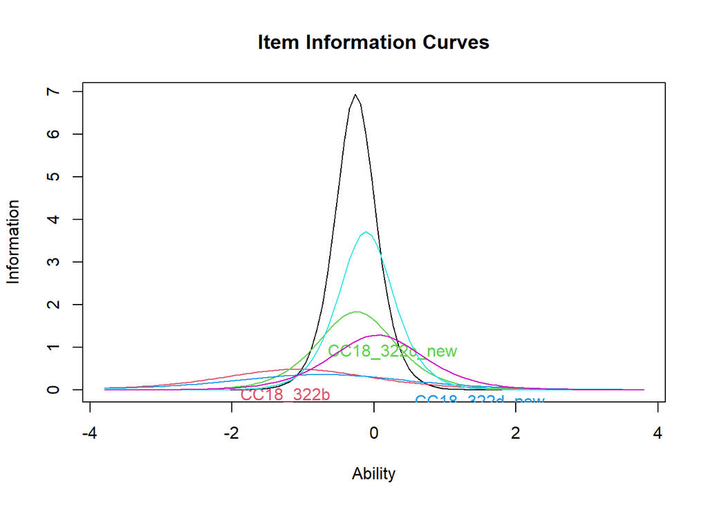

```r
plot(mod_2pl, type="IIC")
```

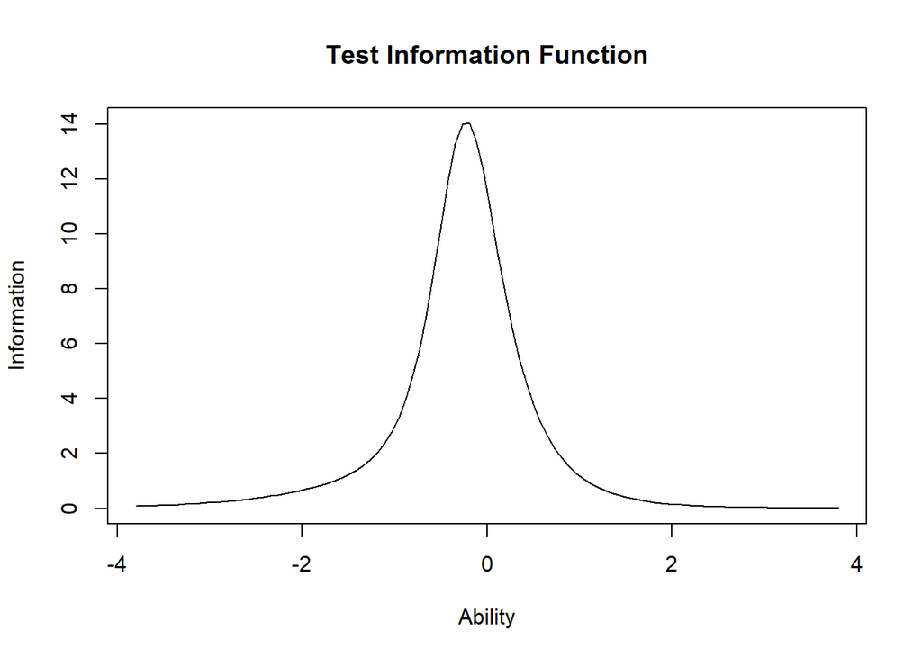

```r
plot(mod_2pl, type="IIC", items=0)
```

It looks like our model did fairly well, but the model is best at explaining people with moderate positions/ no strong opinion on the issue, since the mean of the TIF is centered around 0.

One final diagnostics we can do is to test for unidimensionality, i.e. are we really estimating only ONE latent trait? You can do this by calling `unidimTest()` on the fitted IRT model. The $H_0$ is that the model is of unidimensional, i.e. we are really estimating one latent trait only.

```r
unidimTest(mod_2pl, im, B=10)
```

```
##
## Unidimensionality Check using Modified Parallel Analysis
##
## Call:
## ltm(formula = im ~ z1)
##
## Matrix of tertachoric correlations
##               CC18_322a CC18_322b CC18_322c_new CC18_322d_new CC18_322c
## CC18_322a        1.0000    0.6595        0.7991       -0.6653    0.8707
## CC18_322b        0.6595    1.0000        0.5754        0.0535    0.6255
## CC18_322c_new    0.7991    0.5754        1.0000       -0.5908    0.7754
## CC18_322d_new   -0.6653    0.0535       -0.5908        1.0000   -0.5223
## CC18_322c        0.8707    0.6255        0.7754       -0.5223    1.0000
## CC18_322f        0.7547    0.5304        0.6851       -0.4289    0.7646
##               CC18_322f
## CC18_322a        0.7547
## CC18_322b        0.5304
## CC18_322c_new    0.6851
## CC18_322d_new   -0.4289
## CC18_322c        0.7646
## CC18_322f        1.0000
##
## Alternative hypothesis: the second eigenvalue of the observed data is substantially larger
##          than the second eigenvalue of data under the assumed IRT model
##
## Second eigenvalue in the observed data: 0.9332
## Average of second eigenvalues in Monte Carlo samples: 0.5257
## Monte Carlo samples: 10
## p-value: 0.0909
```

# Acquire Predictions

When doing IRTs of course we want to estimate people’s attitudes (i.e. obtaining a copy of $\theta$ for each individual). You can use the `factor.scores()` function to recover the individual-level $\theta_i$ estimates. The individual $\theta_i$ estimates are stored as the `z1` variable under the object `score.dat`.

```r
preds_2pl <- factor.scores(mod_2pl)
summary(preds_2pl$score.dat$z1)
```

```
##    Min. 1st Qu.  Median    Mean 3rd Qu.    Max.
## -1.3051 -0.4884 -0.2190 -0.1983  0.1026  0.8295
```

# Optional: Try the 3PL model out

Now you can repeat the steps covered above to see if fitting a 3PL/ 4PL model helps with model fit. A 3PL model can be fitted by using `tpm()`.

Martin, AD, and KM Quinn. 2002. “Dynamic Ideal Point Estimation via Markov Chain Monte Carlo for the Us Supreme Court, 1953–1999.” *Political Analysis*.

Tsai, Tsung-han, and Chang-chih Lin. 2017. “Modeling Guessing Components in the Measurement of Political Knowledge.” *Political Analysis* 25 (4): 483–504. https://doi.org/10.1017/pan.2017.21.